# SIBER Analysis of Coral Physiology

Peter Flood and Serena Hackerott

2/8/2024

# Setup

### Load Packages

# Sample Data and Metadata

### Load and Organize Data

### Check Correlation

Physiological variables of interest: Protein (Coral and Symbiont), Biomass (Coral and Symbiont), and Chlorophyll.

# SIBER Ellipses

### Prepare Input Data

#### NMDS Ordination

SIBER runs on a two dimensional data set. So first, we need to reduce the dimensionality of the physiology data. We’re going to do this via Non-Metric Multidimensional Scaling (NMDS) on log+1 transformed physiological metrics of interest.

#### NMDS Model

#### Plot NMDS

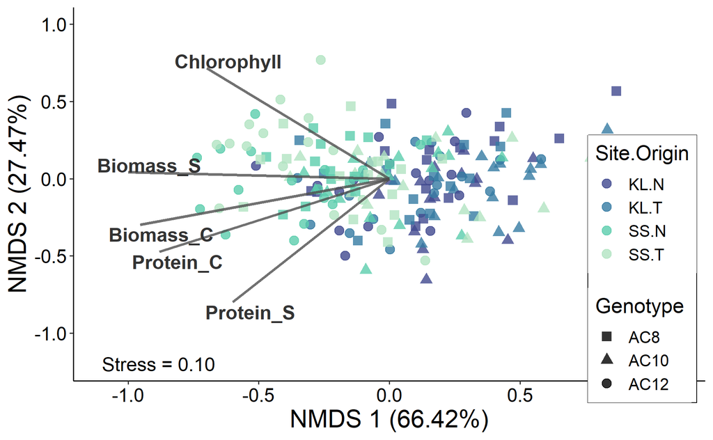

```r
phys.nmds.plot<-ggplot(data = phys.nmds.samples.plot.data, aes(x = MDS1, y = MDS2)) +
  geom_point(data = phys.nmds.samples.plot.data, aes(colour = Site.Orig, shape=Genotype), size = point.sz-1, alpha = 0.8) +
  scale_colour_manual(values =Orig.colors.o)+
  scale_shape_manual(values=Geno.shapes.o)+
  theme_classic()+
  scale_x_continuous(limits = c(-1.1, 1.1))+
  scale_y_continuous(limits = c(-1.2, 1))+
   theme(axis.title.x = element_text(size = axis.title.sz),
        axis.title.y = element_text(size = axis.title.sz),
        axis.text.x=element_text(size=axis.txt.sz, colour="black"),
        axis.text.y=element_text(size=axis.txt.sz, colour="black"),
        legend.text=element_text(size=leg.txt.sz),
        legend.title=element_text(size=leg.title.sz),
        legend.box.background = element_rect(color = "black"),
        legend.position=c(.9, .3))+
  geom_segment(aes(x = 0, y = 0, xend = MDS1, yend = MDS2),
               data = phys.nmds.covariates.plot.data,
               linewidth =bar.sz, alpha = 0.8, colour = "grey30") +
  geom_text(data=phys.nmds.covariates.plot.data,
            aes(x=MDS1, y=MDS2, label=Metric, fontface = "bold",
                hjust=0.15*(1-sign(MDS1)),vjust=0.6*(1-sign(MDS2))),
            colour = "grey20", size=sig.sz)+
  labs(x=paste0('NMDS 1 (',NMDS1,"%)"), y=paste0('NMDS 2 (',NMDS2,"%)"), color="Site.Origin")+
  annotate("text", x = -1.1, y = -1.2, label = NMDS.stress, hjust=0, size=sig.sz); phys.nmds.plot
```

#### Data Prep for SIBER

### Run SIBER

Grouping by each genotype at each site, timepoint, and from each origin

# Ellipse Overlap

### Calculate Percent Overlap

Calculating the overlap of physiological niche space between corals of the same genotype, at the same site and timepoint. Using Percent of Niche Overlap as a more informative indicator of how similar the Transplant corals are to their Native clonemates.

First, calculating the area of the 95% prediction ellipses for each group as well as the maximum likelihood of overlap between physiological niche ellipses.

#### Calculate Niche Areas

#### Calculate Overlap

Proportion of niche overlap = Area of overlap between Native and Transplant physiological niches / Area of the Native niche

Using Native niche area as the denominator which may be more informative as the baseline niche space

### Plot Overlap over Time

#### By Genotype

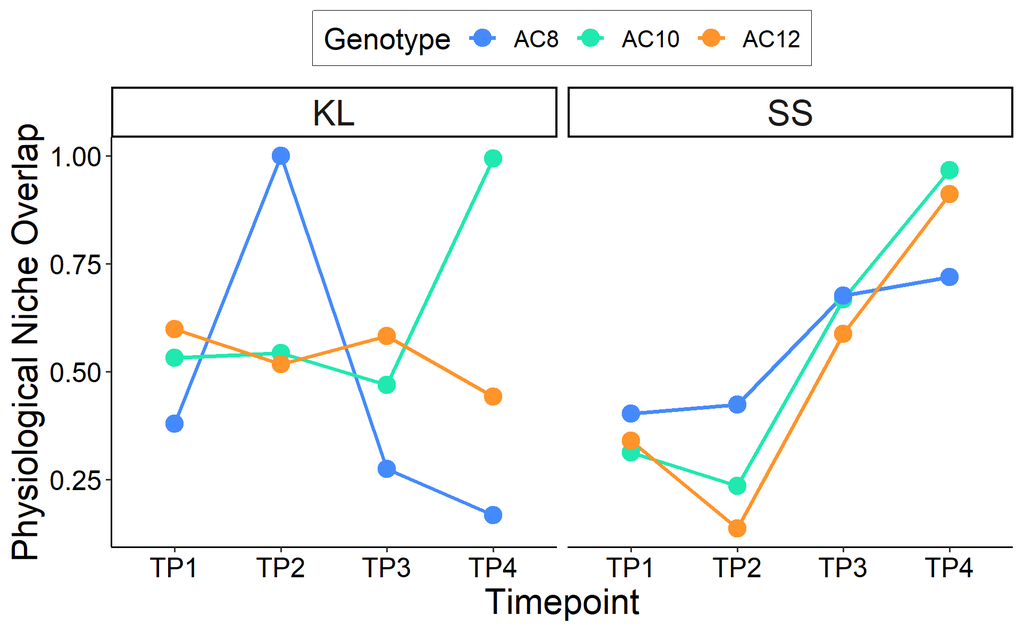

```r
##Plot Niche Overlap across Timepoints
Overlap.plot<-ggplot(Niches, aes(x=TimeP, y=pOverlap, colour=Genotype, group=Genotype)) +
  geom_line(linewidth=bar.sz)+
  geom_point(size=point.sz)+
  scale_colour_manual(values =Geno.colors.o)+
  theme_classic()+
  theme(axis.title.x = element_text(size = axis.title.sz),
        axis.title.y = element_text(size = axis.title.sz),
        axis.text.x=element_text(size=axis.txt.sz, colour="black"),
        axis.text.y=element_text(size=axis.txt.sz, colour="black"),
        legend.text=element_text(size=leg.txt.sz),
        legend.title=element_text(size=leg.title.sz),
        legend.box.background = element_rect(color = "black"),
        legend.position="top",
        strip.text=element_text(size=axis.title.sz))+
  labs(x="Timepoint", y="Physiological Niche Overlap")+
  facet_wrap(~Site); Overlap.plot
```

#### Across Genotypes

#### KL

#### SS

### Differences in Overlap

#### Across Time and Space

```r
##Check Normality
hist(Niches$pOverlap)
shapiro.test(Niches$pOverlap)
#Normal

##Model Overlap as a function of Site and Origin, with Genotype as a Random effect
#Interaction between Site and Timepoint
Overlap.lme<-lmer(pOverlap~TimeP*Site+(1|Genotype), data=Niches)

##Check residuals
Overlap.lme_res <- simulateResiduals(fittedModel = Overlap.lme, plot = F)
plot(Overlap.lme_res)

##Model results
summary(Overlap.lme)
anova(Overlap.lme)
```

#### Pairwise Comparisons

```r
##Timepoints within Sites
emmeans(Overlap.lme, pairwise~TimeP | Site)

##p Values
Overlap.lme.contrast<-data.frame(emmeans(Overlap.lme, pairwise~TimeP | Site)$contrasts)
Overlap.lme.contrast<-Overlap.lme.contrast %>% separate_wider_delim(cols=contrast, names=c("group1", "group2"), delim=" - ", cols_remove=TRUE)
Overlap.lme.contrast$group1<-paste(Overlap.lme.contrast$Site, Overlap.lme.contrast$group1, sep="_")
Overlap.lme.contrast$group2<-paste(Overlap.lme.contrast$Site, Overlap.lme.contrast$group2, sep="_")
```

# Visualize Niche Ellipses

### By Genotype

Plotting 95% prediction ellipses of the physiological niche space for each group, consistent with SIBER ellipse and overlap calculations.

#### KL

#### SS

### By Origin

Plotting 95% confidence intervals of the physiological niche space for each group for visualization of PERMANOVA and PERMDISP results.

#### KL

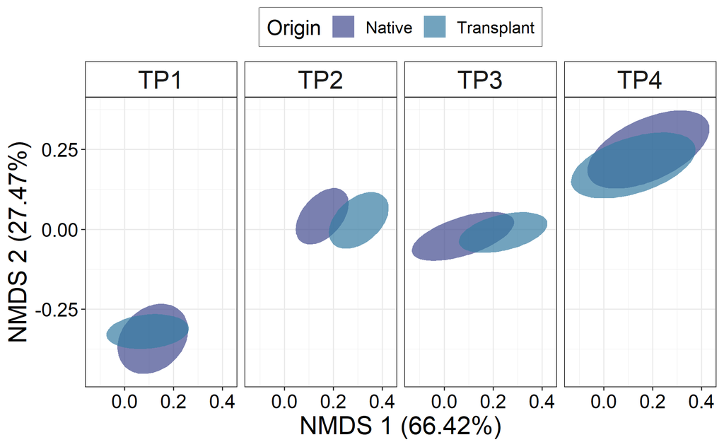

```r
phys.nmds.plot_KL<-ggplot(data = phys.nmds.data_KL, aes(x = MDS1, y = MDS2)) +
  stat_conf_ellipse(geom = "polygon", level = 0.95, alpha = 0.7, aes(fill= Origin))+
  scale_fill_manual(values =Orig.colors.o[1:2])+
  theme_bw()+
   theme(axis.title.x = element_text(size = axis.title.sz),
        axis.title.y = element_text(size = axis.title.sz),
        axis.text.x=element_text(size=axis.txt.sz, colour="black"),
        axis.text.y=element_text(size=axis.txt.sz, colour="black"),
        legend.title=element_text(size=leg.title.sz),
        legend.text=element_text(size=leg.txt.sz),
        legend.box.background = element_rect(color = "black"),
        legend.position="top",
        strip.text = element_text(size=axis.title.sz),
        strip.background=element_rect(fill="white"))+
  labs(x=paste0('NMDS 1 (',NMDS1,"%)"), y=paste0('NMDS 2 (',NMDS2,"%)"))+
  facet_wrap(~TimeP, nrow=1); phys.nmds.plot_KL
```

### SS

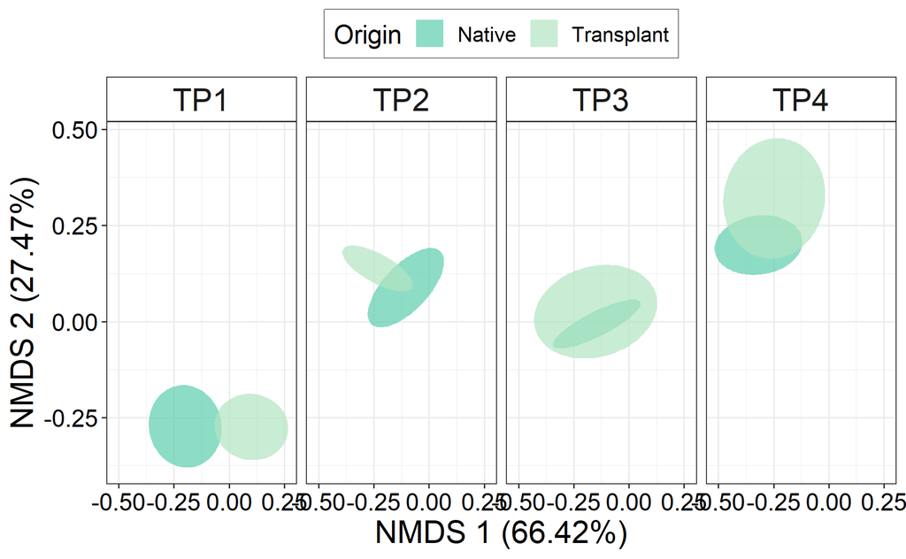

```r
phys.nmds.plot_SS<-ggplot(data = phys.nmds.data_SS, aes(x = MDS1, y = MDS2)) +
  stat_conf_ellipse(geom = "polygon", level = 0.95, alpha = 0.7, aes(fill= Origin))+
  scale_fill_manual(values =Orig.colors.o[3:4])+
  theme_bw()+
   theme(axis.title.x = element_text(size = axis.title.sz),
        axis.title.y = element_text(size = axis.title.sz),
        axis.text.x=element_text(size=axis.txt.sz, colour="black"),
        axis.text.y=element_text(size=axis.txt.sz, colour="black"),
        legend.title=element_text(size=leg.title.sz),
        legend.text=element_text(size=leg.txt.sz),
        legend.box.background = element_rect(color = "black"),
        legend.position="top",
        strip.text = element_text(size=axis.title.sz),
        strip.background=element_rect(fill="white"))+
  labs(x=paste0('NMDS 1 (',NMDS1,"%)"), y=paste0('NMDS 2 (',NMDS2,"%)"))+
  facet_wrap(~TimeP, nrow=1); phys.nmds.plot_SS
```

# Figures

### Figure 3

```r
##Create Panel
NicheOverlap_fig<-plot_grid(phys.nmds.plot_KL, Overlap_Avg_KL.plot,
                      phys.nmds.plot_SS, Overlap_Avg_SS.plot,
                    rel_widths=c(1, .4, 1, .4),
                    rel_heights = c(1, 1, 1, 1),
                    nrow=2, ncol=2, byrow=T,
                    labels = c("A", "C", "B", "D"),
                    label_size=panel.lab.sz)

##Save Figure
ggsave(filename="Figures/02_Physiology/Fig3_AverageNicheOverlap.png", plot=NicheOverlap_fig, dpi=300, width=14, height=9, units="in")
```

### Figure S3

```r
##Create Panel
PhysNiche_fig<-plot_grid(phys.nmds.plot, Overlap.plot,
                    rel_widths=c(1, 0.7),
                    rel_heights = 1,
                    nrow=1, ncol=2, byrow=T,
                    labels = c("A", "B"),
                    label_size=panel.lab.sz)

##Save Figure
ggsave(filename="Figures/02_Physiology/FigS3_PhysiologicalNiche.png", plot=PhysNiche_fig, dpi=300, width=12, height=6, units="in")
```

### Figure S4

```r
##Adjust for Panel
ellipse.plot_KL<-ellipse.plot_KL + ggtitle("Klein Bonaire") +
  theme(plot.title = element_text(colour="black", size=panel.lab.sz, face="bold", hjust=0.5))

ellipse.plot_SS<-ellipse.plot_KL + ggtitle("Something Special") +
  theme(plot.title = element_text(colour="black", size=panel.lab.sz, face="bold", hjust=0.5))

##Create Panel
Ellipse_fig<-plot_grid(ellipse.plot_KL, ellipse.plot_SS,
                    rel_widths=1,
                    rel_heights = 1,
                    nrow=2, ncol=1, byrow=T,
                    labels = NULL)
```

```
Too few points to calculate an ellipseToo few points to calculate an ellipse
```

```r
##Save Figure
ggsave(filename="Figures/02_Physiology/FigS4_PhysiologicalNicheEllipse.png", plot=Ellipse_fig, dpi=300, width=8, height=14, units="in")
```